# Analysis of Scandinavians for Torsten

Adam Finnemann

Nom, 2017

Subsetting scandinavians and section workers + directors. The file missing_scandinavians contains the cotracts not included in this analysis. This is total of 4 people, 3 of them are Temporary Collaborators from the Information Section. Scandinavia is defined as Danes, Swedes and Norwegians.

```r
top_scandi <- da %>%
  filter(nationality %in% c("Dane","Swedish","Norwegian"),
         str_detect(da$fname, "Section") | str_detect(da$fname, "Director"),
         id != "5042", #begin data is before start date.
         fname != "Secretary of Section") %>%
  droplevels()
```

Distribution of fnames for 23 contracts are:

```r
summary(top_scandi$fname)
```

```
##  Chief of Section          Director Member of Section
##                 1                 5                17
```

```r
unique(top_scandi$pname)
```

```
##  [1] Bertil Gotthard Ohlin             Christian Olsen
##  [3] Peter Martin Anker                Peter Christian Schou
##  [5] Essy HjÃ¶rdis Lehmann             John Lindberg
##  [7] Ludwig Thorwald de Krabbe         Per Jacobsson
##  [9] Erik Andreas Colban               Ãke  HammarskjÃ¶ld
## [11] Erik Einan Ekstrand               Bertil Arne Renborg
## [13] Finn Tage Blichfeldt Friis        Johan Ansgar Esaias Rosenborg
## [15] Helmer Rostgaard Gommesen Rosting Dr. Knud Stouman
## [17] Karen Petersen                    Rasmus Ingvald Berentson Skylstad
## 18 Levels: Ãke  HammarskjÃ¶ld ... Rasmus Ingvald Berentson Skylstad
```

There are 18 different people represented.

# 1. question: Distribution of work periods.

Defining function and calculating

```r
#Function for year/worker employment matrix
employment <- function(df, interval = "1 year"){

mdl_df <- df %>%
  select(pname, fname_code,begin_date, end_date) %>%
  mutate(begin_date = as.Date(begin_date),
         end_date = as.Date(end_date))



result <- setDT(mdl_df)[
  .(mseq = seq(as.Date("1919-01-01"), as.Date("1948-12-30"), by = interval)),
  on = .(begin_date <= mseq, end_date >= mseq), nomatch = 0L, allow.cartesian = TRUE][
    , dcast(unique(.SD), pname ~ end_date, toString, value.var = "fname_code")]
}

#function for calcualting employment distributions
employment_distribution <- function(df, xseq = seq(0,30,5),yseq = seq(0,2000, 250), group = "people"){
result <- employment(df)

contract_length <- matrix(nrow = (nrow(result)), ncol = 1)

result <- as.data.frame(result)

names <- as.character(result[,1])

#removing pname column
contracts<- sapply(result[,-1],function(x) x != "") %>%
  rowSums() %>%
  as.data.frame() %>%
  dplyr::rename(contract_length = ".") %>%
  mutate(names = as.factor(names))


contracts %>%
  ggplot(aes(contract_length, color = contract_length)) +
  geom_histogram(binwidth = 1, aes(fill = ..count..)) +
  scale_fill_gradient("count", low="orange", high="purple") +
  labs(x = "Work periods in years", y = "Number of people", title = paste("Distribution of work periods in LoN for",group)) +
  scale_x_continuous(breaks = xseq)+
  scale_y_continuous(breaks = yseq)
}
```

For each scandinavian, how many years in LoN:

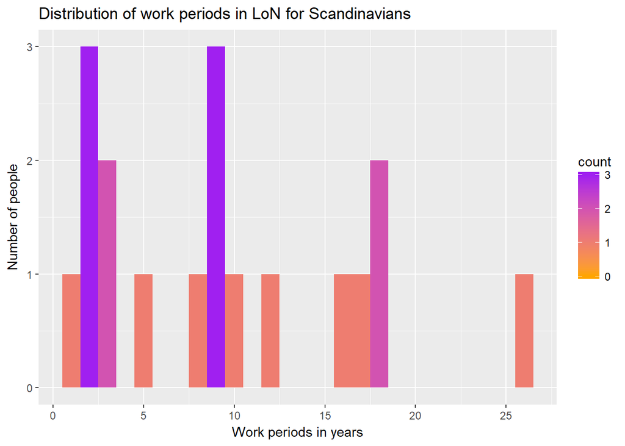

```r
employment_distribution(top_scandi, group = "Scandinavians", yseq = seq(0,5,1))
```

Repeating analysis, only including the first contract for each person

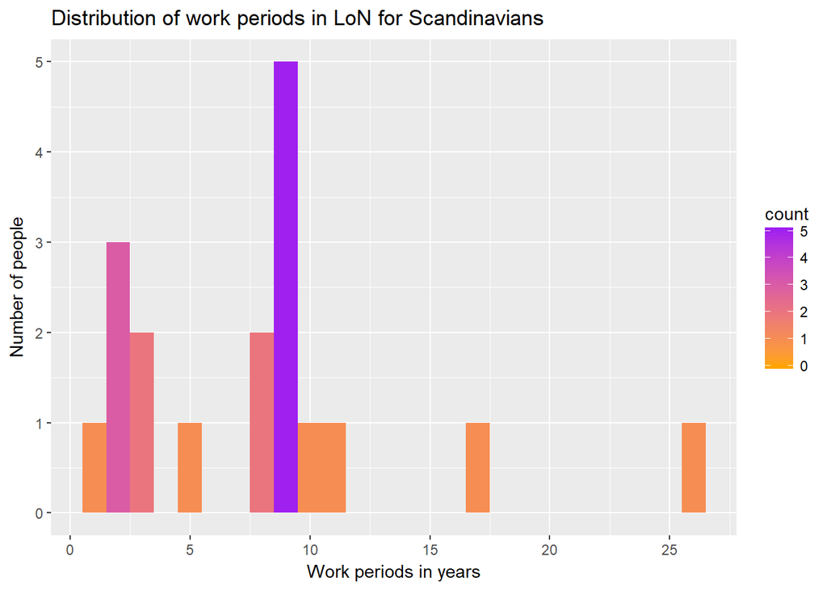

```r
top_scandi %>%
  filter(!duplicated(pname)) %>%
  employment_distribution( group = "Scandinavians", yseq = seq(0,5,1))
```

# Second measure of “lenght of contract”

For each year, how long does contracts from that year last - including all contracts

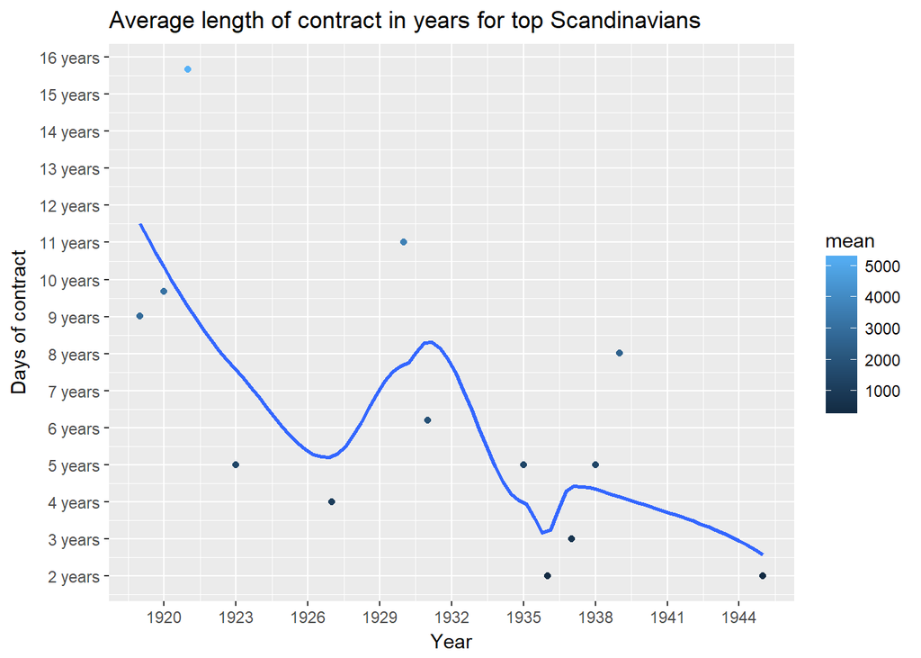

```r
top_scandi <-top_scandi  %>%
  mutate(end_date = as.Date(end_date),
         begin_date = as.Date(begin_date),
         duration = end_date - begin_date,
         duration = as.numeric(duration))

contract_length_per_year <- top_scandi %>%
  mutate(begin_date = as.factor(begin_date)) %>%
  group_by(begin_date) %>%
  dplyr::summarise(mean = mean(duration))



contract_length_per_year %>%
  mutate(begin_date = as.Date(begin_date),
         mean = as.numeric(mean)) %>%
  ggplot(aes(begin_date,mean, color = mean)) +
  geom_point() +
  geom_smooth(se = F) +
  labs(x = "Year", y ="Days of contract", titles = "Average length of contract in years for top Scandinavians")+
  scale_x_date(date_breaks = "3 year", date_labels = "%Y")+
  scale_y_continuous(breaks =seq(0, 30*365, 365),labels = paste(1:length(seq(0, 30*365, 365)), "years"))
```

The line summarising the trend can be change to a straight line if that’s better. The plots includes all top Scandinavian contracts (not just each person’s first contract).

# 2. Distribution of work periods for Scandinavians in first division

Subsetting scandinavians in first division

```r
firstd_scandi <- da %>%
  filter(nationality %in% c("Dane","Swedish","Norwegian"),
         canonical_fname == "First Division",
         id != "5042") %>%  #begin data is before start date.
  droplevels()
```

There are 66 contracts in first division from Scandinavians

```r
unique(firstd_scandi$pname)
```

```
##  [1] Ingvad Nielsen                    Maria Nielsen
##  [3] Birgit Nissen                     Bertil Gotthard Ohlin
##  [5] Christian Olsen                   Haakon Vigander
##  [7] Peter Martin Anker                Th. C. Terndrup
##  [9] Bodil Begtrup                     Peter Christian Schou
## [11] Torsten Cederlund                 Axel Serup
## [13] Magister Morton Bredsdorff        Rasmus Stauri
## [15] Reverend Jacob Steen Narvig       Greta Stendahl
## [17] Dr. Knud Stouman                  HÃ¸jbjerg Christensen
## [19] Essy HjÃ¶rdis Lehmann             John Lindberg
## [21] John Lindgren                     Dr. A. A. Koskenjaakko
## [23] Ludwig Thorwald de Krabbe         Per Jacobsson
## [25] Agnes Jorgensen                   Herald JÃ¸rgensen
## [27] Kaalund Jorgensen                 Erik Bruel
## [29] C.J. Brunskog                     Erik Andreas Colban
## [31] Edvard Hambro                     Victor  Mogens
## [33] Paul Erik Alfred Mohn             Lous  Mohr
## [35] Ãke  HammarskjÃ¶ld               Thora Daugaard
## [37] Bengt Helger                      Carin Hermelin
## [39] Eichelberger                      Erik Einan Ekstrand
## [41] Bertil Arne Renborg               Berit Gulliksen
## [43] Finn Tage Blichfeldt Friis        Ingvald Forfang
## [45] Olaf Ripa                         Johan Ansgar Esaias Rosenborg
## [47] Helmer Rostgaard Gommesen Rosting Kaare Filseth
## [49] Karen Neumann                     Karen Petersen
## [51] Rasmus Ingvald Berentson Skylstad Elisa Jebsen
## [53] Signe Johanne Andersen            Laurits Thomas Arnskov
## [55] Gunhild Lippestad                 Sigurd Hartz-Rasmussen
## [57] Folke Hillgerdt
## 57 Levels: Ãke  HammarskjÃ¶ld Agnes Jorgensen Axel Serup ... Victor  Mogens
```

There are 57 different Scandinavians represented in the first division

Calculating employment intervals

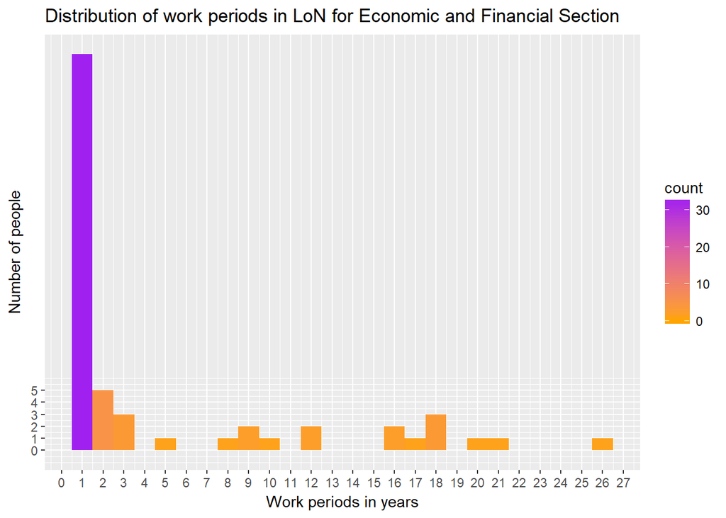

```r
employment_distribution(firstd_scandi,xseq = seq(0,30,1), yseq = seq(0,5,1), group = levels(top_scandi$oname)[5])
```

# Political vs techincals section analysis

Group 1: Social Questions and Opium Traffic Section; Health Section; Communications and Transit Section; Economic and Financial Section; Intellectual Cooperation and International Bureaux Section.

```r
filter(top_scandi, oname %in% c("Social Questions and Opium Traffic Section", "Health Section", "Communications and Transit Section", "Economic and Financial Section", "Intellectual Cooperation and International Bureaux Section")) %>%
  select(-X.1, -X,-id)
```

```
##                   pname gender             fname canonical_fname
## 1 Bertil Gotthard Ohlin      0 Member of Section  First Division
## 2       Christian Olsen      0 Member of Section  First Division
## 3 Essy HjÃ¶rdis Lehmann      1 Member of Section  First Division
## 4         Per Jacobsson      0 Member of Section  First Division
## 5  Erik Einan Ekstrand       0          Director  First Division
## 6   Bertil Arne Renborg      0  Chief of Section  First Division
## 7      Dr. Knud Stouman      0 Member of Section  First Division
##                                        oname born_on_year begin_on_year
## 1             Economic and Financial Section           NA          1931
## 2             Economic and Financial Section           NA          1923
## 3         Communications and Transit Section         1893          1931
## 4             Economic and Financial Section         1894          1920
## 5 Social Questions and Opium Traffic Section         1880          1931
## 6 Social Questions and Opium Traffic Section           NA          1939
```

[output cut: 17 more lines]

There are 7 people represented

Visualizing length of contracts

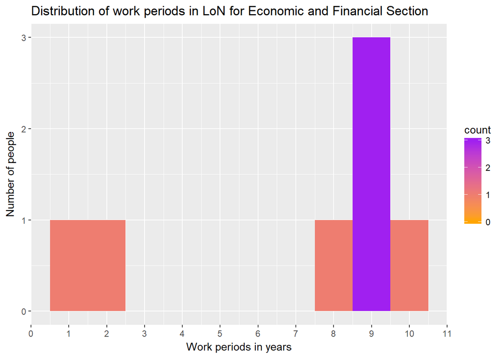

```r
filter(top_scandi, oname %in% c("Social Questions and Opium Traffic Section", "Health Section", "Communications and Transit Section", "Economic and Financial Section", "Intellectual Cooperation and International Bureaux Section")) %>%
  employment_distribution(xseq = seq(0,30,1), yseq = seq(0,5,1), group = levels(top_scandi$oname)[5])
```

```r
filter(top_scandi, oname %in% c("Political Section", "Information Section", "Legal Section", "Disarmament Section" )) %>%
  select(-X.1, X, -gender)
```

```
##      X   id                      pname             fname canonical_fname
## 1 6760 5288  Ludwig Thorwald de Krabbe Member of Section  First Division
## 2 6762 5288  Ludwig Thorwald de Krabbe Member of Section  First Division
## 3 6863 5353        Erik Andreas Colban          Director  First Division
## 4 6910 5393        Ãke  HammarskjÃ¶ld Member of Section  First Division
## 5 7117 5525 Finn Tage Blichfeldt Friis Member of Section  First Division
##                 oname born_on_year begin_on_year begin_on_month
## 1 Information Section         1884          1921              4
## 2   Political Section         1884          1935             10
## 3 Disarmament Section         1876          1927             12
## 4       Legal Section         1893          1920              3
## 5 Disarmament Section         1897          1930              9
##   begin_on_day end_on_year end_on_month end_on_day nationality fname_code
## 1            1        1931            4         16        Dane          8
## 2           27        1939            4         30        Dane          8
## 3           17        1930            7          9   Norwegian          9
## 4           19        1922           NA         NA     Swedish          8
## 5            1        1940            5         27        Dane          8
##   begin_date   end_date duration
## 1 1921-01-01 1931-01-01     3652
## 2 1935-01-01 1939-01-01     1461
## 3 1927-01-01 1930-01-01     1096
## 4 1920-01-01 1922-01-01      731
## 5 1930-01-01 1940-01-01     3652
```

4 People are represented in the second group

calculating distribution of length of contracts

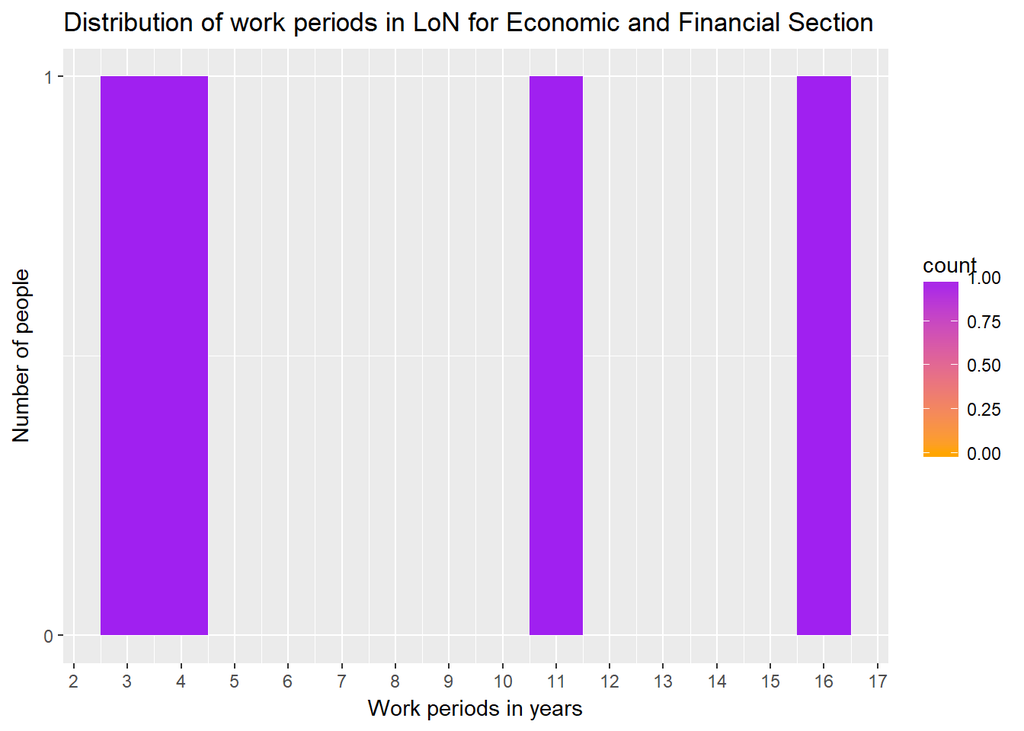

```r
filter(top_scandi, oname %in% c("Political Section", "Information Section", "Legal Section", "Disarmament Section" )) %>%
employment_distribution(xseq = seq(0,30,1), yseq = seq(0,5,1), group = levels(top_scandi$oname)[5])
```

# Breaking down graphs into sections

```r
summary(top_scandi$oname)
```

```
##             Administrative and Minorities Section
##                                                 3
##                Communications and Transit Section
##                                                 1
##      Department I (Department of General Affairs)
##                                                 1
##                               Disarmament Section
##                                                 2
##                    Economic and Financial Section
##                                                 3
## Financial Section & Economic Intelligence Service
##                                                 2
##                                    Health Section
##                                                 1
##                               Information Section
##                                                 1
##                                     Legal Section
##                                                 1
##                                  Mandates Section
##                                                 2
##                                Minorities Section
##                                                 2
##                                 Political Section
##                                                 1
##        Social Questions and Opium Traffic Section
##                                                 2
##                                          Treasury
##                                                 1
```

```r
knitr::opts_chunk$set(rows.print=40)

top_scandi %>%
   mutate(end_date = as.Date(end_date),
          being_date = as.Date(begin_date),
          duration = difftime(end_date, begin_date, units = "days")) %>%
  select(pname, oname, duration)
```

```
##                                pname
## 1              Bertil Gotthard Ohlin
## 2                    Christian Olsen
## 3                 Peter Martin Anker
## 4                 Peter Martin Anker
## 5              Peter Christian Schou
## 6              Essy HjÃ¶rdis Lehmann
## 7                      John Lindberg
## 8          Ludwig Thorwald de Krabbe
## 9          Ludwig Thorwald de Krabbe
## 10         Ludwig Thorwald de Krabbe
## 11                     Per Jacobsson
## 12               Erik Andreas Colban
## 13               Erik Andreas Colban
## 14               Ãke  HammarskjÃ¶ld
```

[output cut: 33 more lines]

Plotting the distribution of work periods for the sections with more than 2 contracts.

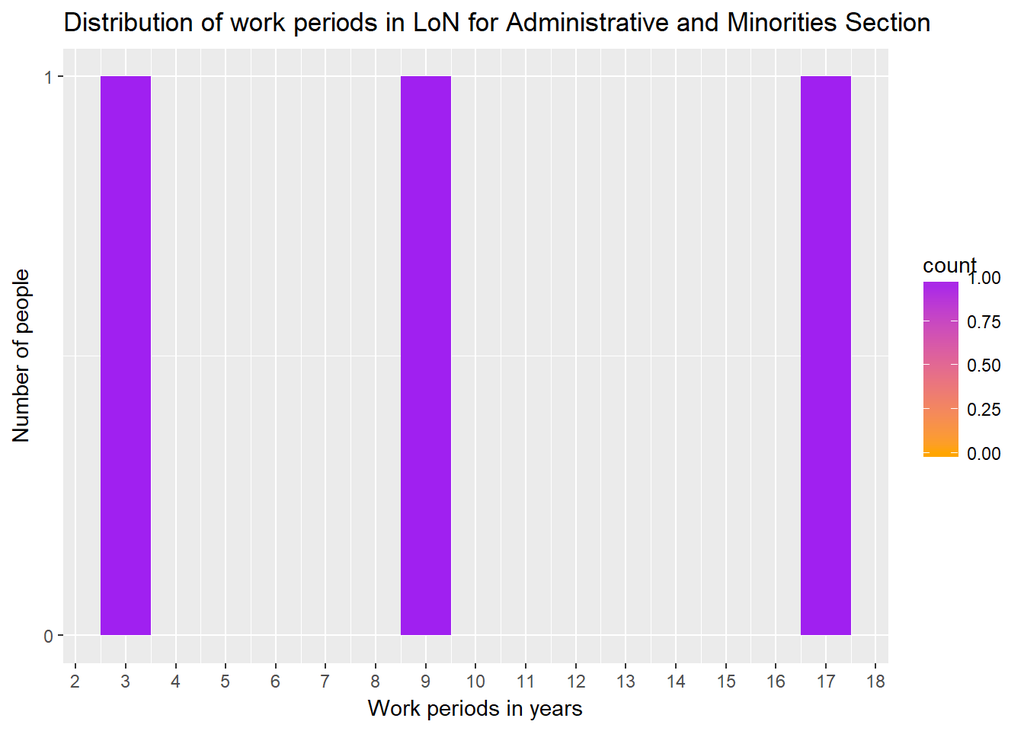

```r
employment_distribution(filter(top_scandi, oname == levels(oname)[1]),xseq = seq(0,30,1), yseq = seq(0,5,1), group = levels(top_scandi$oname)[1])
```

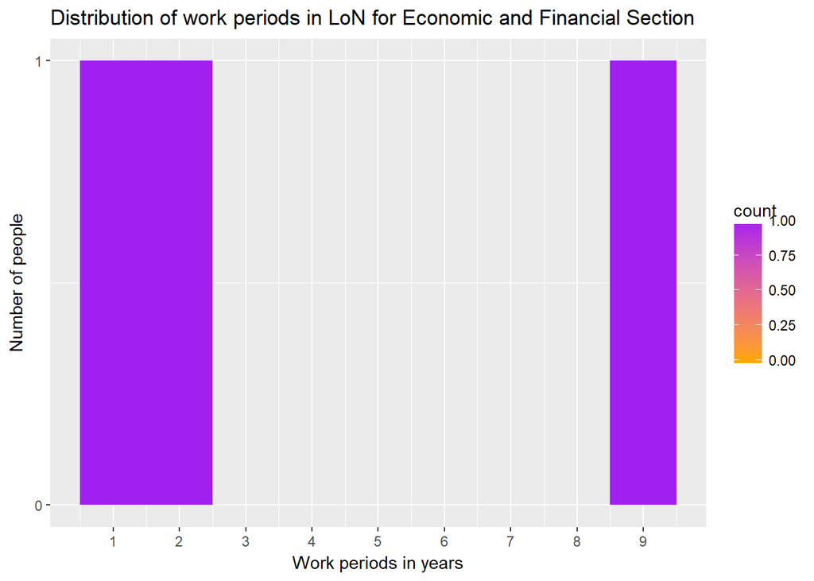

```r
employment_distribution(filter(top_scandi, oname == levels(oname)[5]),xseq = seq(0,30,1), yseq = seq(0,5,1), group = levels(top_scandi$oname)[5])
```